# Optimal Treatment Analysis

## Outcome Variable

**Outcome Variable:** ever_wasted

## Predictor Variables

**Intervention Variable:** hdlvry

**Adjustment Set:**

- arm
- sex
- W_mage
- meducyrs
- feducyrs
- single
- W_nrooms
- W_parity
- impsan
- delta_W_mage
- delta_meducyrs
- delta_feducyrs
- delta_single
- delta_W_nrooms
- delta_W_parity
- delta_impsan

## Stratifying Variables

The analysis was stratified on these variable(s):

- agecat
- studyid
- country

## Data Summary

| agecat | studyid | country | hdlvry | ever_wasted | n_cell | n |
| --- | --- | --- | --- | --- | --- | --- |
| 0-24 months (no birth wast) | ki1000108-CMC-V-BCS-2002 | INDIA | 0 | 0 | 196 | 365 |
| 0-24 months (no birth wast) | ki1000108-CMC-V-BCS-2002 | INDIA | 0 | 1 | 161 | 365 |
| 0-24 months (no birth wast) | ki1000108-CMC-V-BCS-2002 | INDIA | 1 | 0 | 5 | 365 |
| 0-24 months (no birth wast) | ki1000108-CMC-V-BCS-2002 | INDIA | 1 | 1 | 3 | 365 |
| 0-24 months (no birth wast) | ki1000108-IRC | INDIA | 0 | 0 | 190 | 409 |
| 0-24 months (no birth wast) | ki1000108-IRC | INDIA | 0 | 1 | 211 | 409 |
| 0-24 months (no birth wast) | ki1000108-IRC | INDIA | 1 | 0 | 6 | 409 |
| 0-24 months (no birth wast) | ki1000108-IRC | INDIA | 1 | 1 | 2 | 409 |
| 0-24 months (no birth wast) | ki1000109-EE | PAKISTAN | 0 | 0 | 143 | 375 |
| 0-24 months (no birth wast) | ki1000109-EE | PAKISTAN | 0 | 1 | 109 | 375 |
| 0-24 months (no birth wast) | ki1000109-EE | PAKISTAN | 1 | 0 | 68 | 375 |
| 0-24 months (no birth wast) | ki1000109-EE | PAKISTAN | 1 | 1 | 55 | 375 |
| 0-24 months (no birth wast) | ki1000304b-SAS-CompFeed | INDIA | 0 | 0 | 57 | 395 |
| 0-24 months (no birth wast) | ki1000304b-SAS-CompFeed | INDIA | 0 | 1 | 20 | 395 |
| 0-24 months (no birth wast) | ki1000304b-SAS-CompFeed | INDIA | 1 | 0 | 198 | 395 |
| 0-24 months (no birth wast) | ki1000304b-SAS-CompFeed | INDIA | 1 | 1 | 120 | 395 |
| 0-24 months (no birth wast) | ki1000304b-SAS-FoodSuppl | INDIA | 0 | 0 | 17 | 100 |
| 0-24 months (no birth wast) | ki1000304b-SAS-FoodSuppl | INDIA | 0 | 1 | 6 | 100 |
| 0-24 months (no birth wast) | ki1000304b-SAS-FoodSuppl | INDIA | 1 | 0 | 43 | 100 |
| 0-24 months (no birth wast) | ki1000304b-SAS-FoodSuppl | INDIA | 1 | 1 | 34 | 100 |
| 0-24 months (no birth wast) | ki1017093b-PROVIDE | BANGLADESH | 0 | 0 | 427 | 687 |
| 0-24 months (no birth wast) | ki1017093b-PROVIDE | BANGLADESH | 0 | 1 | 86 | 687 |
| 0-24 months (no birth wast) | ki1017093b-PROVIDE | BANGLADESH | 1 | 0 | 138 | 687 |
| 0-24 months (no birth wast) | ki1017093b-PROVIDE | BANGLADESH | 1 | 1 | 36 | 687 |
| 0-24 months (no birth wast) | ki1017093c-NIH-Crypto | BANGLADESH | 0 | 0 | 513 | 754 |
| 0-24 months (no birth wast) | ki1017093c-NIH-Crypto | BANGLADESH | 0 | 1 | 74 | 754 |
| 0-24 months (no birth wast) | ki1017093c-NIH-Crypto | BANGLADESH | 1 | 0 | 133 | 754 |
| 0-24 months (no birth wast) | ki1017093c-NIH-Crypto | BANGLADESH | 1 | 1 | 34 | 754 |
| 0-24 months (no birth wast) | ki1066203-TanzaniaChild2 | TANZANIA, UNITED REPUBLIC OF | 0 | 0 | 1776 | 2262 |
| 0-24 months (no birth wast) | ki1066203-TanzaniaChild2 | TANZANIA, UNITED REPUBLIC OF | 0 | 1 | 446 | 2262 |

[output cut: 114 more lines]

The following strata were considered:

- agecat: 0-24 months (no birth wast), studyid: ki1000108-CMC-V-BCS-2002, country: INDIA
- agecat: 0-24 months (no birth wast), studyid: ki1000108-IRC, country: INDIA
- agecat: 0-24 months (no birth wast), studyid: ki1000109-EE, country: PAKISTAN
- agecat: 0-24 months (no birth wast), studyid: ki1000304b-SAS-CompFeed, country: INDIA
- agecat: 0-24 months (no birth wast), studyid: ki1000304b-SAS-FoodSuppl, country: INDIA
- agecat: 0-24 months (no birth wast), studyid: ki1017093b-PROVIDE, country: BANGLADESH
- agecat: 0-24 months (no birth wast), studyid: ki1017093c-NIH-Crypto, country: BANGLADESH
- agecat: 0-24 months (no birth wast), studyid: ki1066203-TanzaniaChild2, country: TANZANIA, UNITED REPUBLIC OF
- agecat: 0-24 months (no birth wast), studyid: ki1113344-GMS-Nepal, country: NEPAL
- agecat: 0-24 months (no birth wast), studyid: ki1135781-COHORTS, country: INDIA
- agecat: 0-24 months (no birth wast), studyid: kiGH5241-JiVitA-3, country: BANGLADESH
- agecat: 0-24 months (no birth wast), studyid: kiGH5241-JiVitA-4, country: BANGLADESH
- agecat: 0-6 months (no birth wast), studyid: ki1000108-CMC-V-BCS-2002, country: INDIA
- agecat: 0-6 months (no birth wast), studyid: ki1000108-IRC, country: INDIA
- agecat: 0-6 months (no birth wast), studyid: ki1000109-EE, country: PAKISTAN
- agecat: 0-6 months (no birth wast), studyid: ki1000304b-SAS-CompFeed, country: INDIA
- agecat: 0-6 months (no birth wast), studyid: ki1000304b-SAS-FoodSuppl, country: INDIA
- agecat: 0-6 months (no birth wast), studyid: ki1017093b-PROVIDE, country: BANGLADESH
- agecat: 0-6 months (no birth wast), studyid: ki1017093c-NIH-Crypto, country: BANGLADESH
- agecat: 0-6 months (no birth wast), studyid: ki1066203-TanzaniaChild2, country: TANZANIA, UNITED REPUBLIC OF
- agecat: 0-6 months (no birth wast), studyid: ki1113344-GMS-Nepal, country: NEPAL
- agecat: 0-6 months (no birth wast), studyid: ki1135781-COHORTS, country: INDIA
- agecat: 0-6 months (no birth wast), studyid: kiGH5241-JiVitA-3, country: BANGLADESH
- agecat: 0-6 months (no birth wast), studyid: kiGH5241-JiVitA-4, country: BANGLADESH
- agecat: 6-24 months, studyid: ki1000108-CMC-V-BCS-2002, country: INDIA
- agecat: 6-24 months, studyid: ki1000108-IRC, country: INDIA
- agecat: 6-24 months, studyid: ki1000109-EE, country: PAKISTAN
- agecat: 6-24 months, studyid: ki1000304b-SAS-CompFeed, country: INDIA
- agecat: 6-24 months, studyid: ki1000304b-SAS-FoodSuppl, country: INDIA
- agecat: 6-24 months, studyid: ki1017093b-PROVIDE, country: BANGLADESH
- agecat: 6-24 months, studyid: ki1017093c-NIH-Crypto, country: BANGLADESH
- agecat: 6-24 months, studyid: ki1066203-TanzaniaChild2, country: TANZANIA, UNITED REPUBLIC OF
- agecat: 6-24 months, studyid: ki1113344-GMS-Nepal, country: NEPAL
- agecat: 6-24 months, studyid: ki1135781-COHORTS, country: INDIA
- agecat: 6-24 months, studyid: kiGH5241-JiVitA-3, country: BANGLADESH
- agecat: 6-24 months, studyid: kiGH5241-JiVitA-4, country: BANGLADESH

### Dropped Strata

Some strata were dropped due to rare outcomes:

- agecat: 0-24 months (no birth wast), studyid: ki1000108-CMC-V-BCS-2002, country: INDIA
- agecat: 0-24 months (no birth wast), studyid: ki1000108-IRC, country: INDIA
- agecat: 0-24 months (no birth wast), studyid: kiGH5241-JiVitA-3, country: BANGLADESH
- agecat: 0-6 months (no birth wast), studyid: ki1000108-CMC-V-BCS-2002, country: INDIA
- agecat: 0-6 months (no birth wast), studyid: ki1000108-IRC, country: INDIA
- agecat: 0-6 months (no birth wast), studyid: ki1000304b-SAS-FoodSuppl, country: INDIA
- agecat: 0-6 months (no birth wast), studyid: ki1066203-TanzaniaChild2, country: TANZANIA, UNITED REPUBLIC OF
- agecat: 0-6 months (no birth wast), studyid: kiGH5241-JiVitA-3, country: BANGLADESH
- agecat: 6-24 months, studyid: ki1000108-CMC-V-BCS-2002, country: INDIA
- agecat: 6-24 months, studyid: ki1000108-IRC, country: INDIA
- agecat: 6-24 months, studyid: ki1066203-TanzaniaChild2, country: TANZANIA, UNITED REPUBLIC OF
- agecat: 6-24 months, studyid: kiGH5241-JiVitA-3, country: BANGLADESH

## Methods Detail

We’re interested in the causal parameters $E[Y_a]$ for all values of $a \in \mathcal{A}$. These parameters represent the mean outcome if, possibly contrary to fact, we intervened to set all units to have $A=a$. Under the randomization and positivity assumptions, these are identified by the statistical parameters $\psi_a=E_W[E_{Y|A,W}(Y|A=a,W)]$. In addition, we’re interested in the mean of $Y$, $E[Y]$ under no intervention (the observed mean). We will estimate these parameters by using SuperLearner to fit the relevant likelihood factors – $E_{Y|A,W}(Y|A=a,W)$ and $p(A=a|W)$, and then updating our likelihood fit using a joint TMLE.

For unadjusted analyses ($W=\{\}$), initial likelihoods were estimated using Lrnr_glm to estimate the simple $E(Y|A)$ and Lrnr_mean to estimate $p(A)$. For adjusted analyses, a small library containing Lrnr_glmnet, Lrnr_xgboost, and Lrnr_mean was used.

Having estimated these parameters, we will then use the delta method to estimate relative risks and attributable risks relative to a prespecified baseline level of $A$.

# Results Detail

## Results Plots

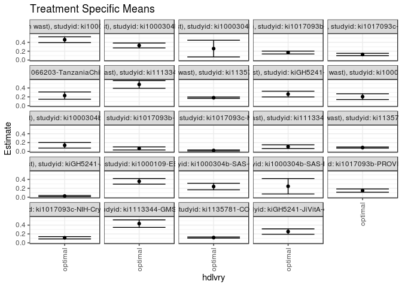

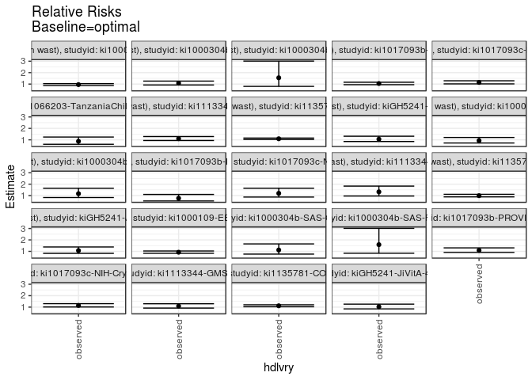

## Results Table

### Parameter: TSM

| agecat | studyid | country | intervention_level | baseline_level | estimate | ci_lower | ci_upper |
| --- | --- | --- | --- | --- | --- | --- | --- |
| 0-24 months (no birth wast) | ki1000109-EE | PAKISTAN | optimal | NA | 0.4586215 | 0.3924185 | 0.5248245 |
| 0-24 months (no birth wast) | ki1000304b-SAS-CompFeed | INDIA | optimal | NA | 0.3285011 | 0.2729257 | 0.3840766 |
| 0-24 months (no birth wast) | ki1000304b-SAS-FoodSuppl | INDIA | optimal | NA | 0.2581149 | 0.0697156 | 0.4465142 |
| 0-24 months (no birth wast) | ki1017093b-PROVIDE | BANGLADESH | optimal | NA | 0.1691652 | 0.1367946 | 0.2015359 |
| 0-24 months (no birth wast) | ki1017093c-NIH-Crypto | BANGLADESH | optimal | NA | 0.1251027 | 0.0983968 | 0.1518087 |
| 0-24 months (no birth wast) | ki1066203-TanzaniaChild2 | TANZANIA, UNITED REPUBLIC OF | optimal | NA | 0.2292895 | 0.1470981 | 0.3114810 |
| 0-24 months (no birth wast) | ki1113344-GMS-Nepal | NEPAL | optimal | NA | 0.4802991 | 0.3937263 | 0.5668719 |
| 0-24 months (no birth wast) | ki1135781-COHORTS | INDIA | optimal | NA | 0.1808925 | 0.1660953 | 0.1956897 |
| 0-24 months (no birth wast) | kiGH5241-JiVitA-4 | BANGLADESH | optimal | NA | 0.2628269 | 0.1979115 | 0.3277422 |
| 0-6 months (no birth wast) | ki1000109-EE | PAKISTAN | optimal | NA | 0.2048107 | 0.1394443 | 0.2701771 |
| 0-6 months (no birth wast) | ki1000304b-SAS-CompFeed | INDIA | optimal | NA | 0.1390742 | 0.0763318 | 0.2018167 |
| 0-6 months (no birth wast) | ki1017093b-PROVIDE | BANGLADESH | optimal | NA | 0.0687516 | 0.0343017 | 0.1032016 |
| 0-6 months (no birth wast) | ki1017093c-NIH-Crypto | BANGLADESH | optimal | NA | 0.0222774 | 0.0102910 | 0.0342637 |
| 0-6 months (no birth wast) | ki1113344-GMS-Nepal | NEPAL | optimal | NA | 0.1068148 | 0.0650243 | 0.1486053 |
| 0-6 months (no birth wast) | ki1135781-COHORTS | INDIA | optimal | NA | 0.0873420 | 0.0744956 | 0.1001884 |
| 0-6 months (no birth wast) | kiGH5241-JiVitA-4 | BANGLADESH | optimal | NA | 0.0249998 | 0.0130308 | 0.0369688 |
| 6-24 months | ki1000109-EE | PAKISTAN | optimal | NA | 0.3565926 | 0.2937152 | 0.4194701 |
| 6-24 months | ki1000304b-SAS-CompFeed | INDIA | optimal | NA | 0.2388734 | 0.1656435 | 0.3121033 |
| 6-24 months | ki1000304b-SAS-FoodSuppl | INDIA | optimal | NA | 0.2450973 | 0.0712772 | 0.4189174 |
| 6-24 months | ki1017093b-PROVIDE | BANGLADESH | optimal | NA | 0.1478193 | 0.1107679 | 0.1848707 |
| 6-24 months | ki1017093c-NIH-Crypto | BANGLADESH | optimal | NA | 0.1146220 | 0.0883941 | 0.1408499 |
| 6-24 months | ki1113344-GMS-Nepal | NEPAL | optimal | NA | 0.4335620 | 0.3484523 | 0.5186717 |
| 6-24 months | ki1135781-COHORTS | INDIA | optimal | NA | 0.1188536 | 0.1060969 | 0.1316103 |
| 6-24 months | kiGH5241-JiVitA-4 | BANGLADESH | optimal | NA | 0.2548679 | 0.1941530 | 0.3155827 |

### Parameter: E(Y)

| agecat | studyid | country | intervention_level | baseline_level | estimate | ci_lower | ci_upper |
| --- | --- | --- | --- | --- | --- | --- | --- |
| 0-24 months (no birth wast) | ki1000109-EE | PAKISTAN | observed | NA | 0.4373333 | 0.3870592 | 0.4876074 |
| 0-24 months (no birth wast) | ki1000304b-SAS-CompFeed | INDIA | observed | NA | 0.3544304 | 0.2614867 | 0.4473741 |
| 0-24 months (no birth wast) | ki1000304b-SAS-FoodSuppl | INDIA | observed | NA | 0.4000000 | 0.3034980 | 0.4965020 |
| 0-24 months (no birth wast) | ki1017093b-PROVIDE | BANGLADESH | observed | NA | 0.1775837 | 0.1489858 | 0.2061816 |
| 0-24 months (no birth wast) | ki1017093c-NIH-Crypto | BANGLADESH | observed | NA | 0.1432361 | 0.1182149 | 0.1682572 |
| 0-24 months (no birth wast) | ki1066203-TanzaniaChild2 | TANZANIA, UNITED REPUBLIC OF | observed | NA | 0.2002653 | 0.1837694 | 0.2167611 |
| 0-24 months (no birth wast) | ki1113344-GMS-Nepal | NEPAL | observed | NA | 0.5290909 | 0.4873371 | 0.5708447 |
| 0-24 months (no birth wast) | ki1135781-COHORTS | INDIA | observed | NA | 0.1978741 | 0.1867089 | 0.2090392 |
| 0-24 months (no birth wast) | kiGH5241-JiVitA-4 | BANGLADESH | observed | NA | 0.2787724 | 0.2485492 | 0.3089955 |
| 0-6 months (no birth wast) | ki1000109-EE | PAKISTAN | observed | NA | 0.1913747 | 0.1512914 | 0.2314579 |
| 0-6 months (no birth wast) | ki1000304b-SAS-CompFeed | INDIA | observed | NA | 0.1623711 | 0.0945196 | 0.2302227 |
| 0-6 months (no birth wast) | ki1017093b-PROVIDE | BANGLADESH | observed | NA | 0.0527086 | 0.0359384 | 0.0694789 |
| 0-6 months (no birth wast) | ki1017093c-NIH-Crypto | BANGLADESH | observed | NA | 0.0267023 | 0.0151493 | 0.0382553 |
| 0-6 months (no birth wast) | ki1113344-GMS-Nepal | NEPAL | observed | NA | 0.1417769 | 0.1120237 | 0.1715302 |
| 0-6 months (no birth wast) | ki1135781-COHORTS | INDIA | observed | NA | 0.0867694 | 0.0784641 | 0.0950747 |
| 0-6 months (no birth wast) | kiGH5241-JiVitA-4 | BANGLADESH | observed | NA | 0.0267380 | 0.0164185 | 0.0370574 |
| 6-24 months | ki1000109-EE | PAKISTAN | observed | NA | 0.3297587 | 0.2819849 | 0.3775326 |
| 6-24 months | ki1000304b-SAS-CompFeed | INDIA | observed | NA | 0.2673797 | 0.2109177 | 0.3238416 |
| 6-24 months | ki1000304b-SAS-FoodSuppl | INDIA | observed | NA | 0.3883495 | 0.2937670 | 0.4829321 |
| 6-24 months | ki1017093b-PROVIDE | BANGLADESH | observed | NA | 0.1609756 | 0.1319065 | 0.1900447 |
| 6-24 months | ki1017093c-NIH-Crypto | BANGLADESH | observed | NA | 0.1315068 | 0.1069744 | 0.1560393 |
| 6-24 months | ki1113344-GMS-Nepal | NEPAL | observed | NA | 0.4717668 | 0.4299709 | 0.5135628 |
| 6-24 months | ki1135781-COHORTS | INDIA | observed | NA | 0.1326445 | 0.1229894 | 0.1422995 |
| 6-24 months | kiGH5241-JiVitA-4 | BANGLADESH | observed | NA | 0.2627119 | 0.2334227 | 0.2920010 |

### Parameter: RR

| agecat | studyid | country | intervention_level | baseline_level | estimate | ci_lower | ci_upper |
| --- | --- | --- | --- | --- | --- | --- | --- |
| 0-24 months (no birth wast) | ki1000109-EE | PAKISTAN | observed | optimal | 0.9535823 | 0.8736974 | 1.040771 |
| 0-24 months (no birth wast) | ki1000304b-SAS-CompFeed | INDIA | observed | optimal | 1.0789320 | 0.9226106 | 1.261739 |
| 0-24 months (no birth wast) | ki1000304b-SAS-FoodSuppl | INDIA | observed | optimal | 1.5496974 | 0.7983298 | 3.008233 |
| 0-24 months (no birth wast) | ki1017093b-PROVIDE | BANGLADESH | observed | optimal | 1.0497646 | 0.9484817 | 1.161863 |
| 0-24 months (no birth wast) | ki1017093c-NIH-Crypto | BANGLADESH | observed | optimal | 1.1449476 | 1.0164419 | 1.289700 |
| 0-24 months (no birth wast) | ki1066203-TanzaniaChild2 | TANZANIA, UNITED REPUBLIC OF | observed | optimal | 0.8734164 | 0.6127459 | 1.244980 |
| 0-24 months (no birth wast) | ki1113344-GMS-Nepal | NEPAL | observed | optimal | 1.1015863 | 0.9419030 | 1.288341 |
| 0-24 months (no birth wast) | ki1135781-COHORTS | INDIA | observed | optimal | 1.0938767 | 1.0330073 | 1.158333 |
| 0-24 months (no birth wast) | kiGH5241-JiVitA-4 | BANGLADESH | observed | optimal | 1.0606692 | 0.8544082 | 1.316723 |
| 0-6 months (no birth wast) | ki1000109-EE | PAKISTAN | observed | optimal | 0.9343979 | 0.7231159 | 1.207413 |
| 0-6 months (no birth wast) | ki1000304b-SAS-CompFeed | INDIA | observed | optimal | 1.1675143 | 0.8306998 | 1.640893 |
| 0-6 months (no birth wast) | ki1017093b-PROVIDE | BANGLADESH | observed | optimal | 0.7666528 | 0.5333264 | 1.102058 |
| 0-6 months (no birth wast) | ki1017093c-NIH-Crypto | BANGLADESH | observed | optimal | 1.1986284 | 0.8730802 | 1.645565 |
| 0-6 months (no birth wast) | ki1113344-GMS-Nepal | NEPAL | observed | optimal | 1.3273156 | 0.9625345 | 1.830341 |
| 0-6 months (no birth wast) | ki1135781-COHORTS | INDIA | observed | optimal | 0.9934438 | 0.8872543 | 1.112343 |
| 0-6 months (no birth wast) | kiGH5241-JiVitA-4 | BANGLADESH | observed | optimal | 1.0695271 | 0.8274258 | 1.382466 |
| 6-24 months | ki1000109-EE | PAKISTAN | observed | optimal | 0.9247491 | 0.8289059 | 1.031674 |
| 6-24 months | ki1000304b-SAS-CompFeed | INDIA | observed | optimal | 1.1193364 | 0.7593832 | 1.649910 |
| 6-24 months | ki1000304b-SAS-FoodSuppl | INDIA | observed | optimal | 1.5844708 | 0.8330633 | 3.013634 |
| 6-24 months | ki1017093b-PROVIDE | BANGLADESH | observed | optimal | 1.0890029 | 0.9089081 | 1.304782 |
| 6-24 months | ki1017093c-NIH-Crypto | BANGLADESH | observed | optimal | 1.1473089 | 1.0100523 | 1.303217 |
| 6-24 months | ki1113344-GMS-Nepal | NEPAL | observed | optimal | 1.0881185 | 0.9167726 | 1.291489 |
| 6-24 months | ki1135781-COHORTS | INDIA | observed | optimal | 1.1160324 | 1.0326837 | 1.206108 |
| 6-24 months | kiGH5241-JiVitA-4 | BANGLADESH | observed | optimal | 1.0307768 | 0.8436698 | 1.259380 |

### Parameter: PAR

| agecat | studyid | country | intervention_level | baseline_level | estimate | ci_lower | ci_upper |
| --- | --- | --- | --- | --- | --- | --- | --- |
| 0-24 months (no birth wast) | ki1000109-EE | PAKISTAN | optimal | NA | -0.0212881 | -0.0614843 | 0.0189081 |
| 0-24 months (no birth wast) | ki1000304b-SAS-CompFeed | INDIA | optimal | NA | 0.0259292 | -0.0309966 | 0.0828550 |
| 0-24 months (no birth wast) | ki1000304b-SAS-FoodSuppl | INDIA | optimal | NA | 0.1418851 | -0.0290420 | 0.3128121 |
| 0-24 months (no birth wast) | ki1017093b-PROVIDE | BANGLADESH | optimal | NA | 0.0084184 | -0.0087822 | 0.0256191 |
| 0-24 months (no birth wast) | ki1017093c-NIH-Crypto | BANGLADESH | optimal | NA | 0.0181333 | 0.0029725 | 0.0332941 |
| 0-24 months (no birth wast) | ki1066203-TanzaniaChild2 | TANZANIA, UNITED REPUBLIC OF | optimal | NA | -0.0290243 | -0.1101728 | 0.0521242 |
| 0-24 months (no birth wast) | ki1113344-GMS-Nepal | NEPAL | optimal | NA | 0.0487918 | -0.0262529 | 0.1238365 |
| 0-24 months (no birth wast) | ki1135781-COHORTS | INDIA | optimal | NA | 0.0169816 | 0.0066146 | 0.0273486 |
| 0-24 months (no birth wast) | kiGH5241-JiVitA-4 | BANGLADESH | optimal | NA | 0.0159455 | -0.0408244 | 0.0727154 |
| 0-6 months (no birth wast) | ki1000109-EE | PAKISTAN | optimal | NA | -0.0134360 | -0.0658088 | 0.0389368 |
| 0-6 months (no birth wast) | ki1000304b-SAS-CompFeed | INDIA | optimal | NA | 0.0232969 | -0.0278611 | 0.0744549 |
| 0-6 months (no birth wast) | ki1017093b-PROVIDE | BANGLADESH | optimal | NA | -0.0160430 | -0.0418999 | 0.0098139 |
| 0-6 months (no birth wast) | ki1017093c-NIH-Crypto | BANGLADESH | optimal | NA | 0.0044249 | -0.0028772 | 0.0117271 |
| 0-6 months (no birth wast) | ki1113344-GMS-Nepal | NEPAL | optimal | NA | 0.0349621 | 0.0001706 | 0.0697537 |
| 0-6 months (no birth wast) | ki1135781-COHORTS | INDIA | optimal | NA | -0.0005726 | -0.0104457 | 0.0093004 |
| 0-6 months (no birth wast) | kiGH5241-JiVitA-4 | BANGLADESH | optimal | NA | 0.0017382 | -0.0046644 | 0.0081407 |
| 6-24 months | ki1000109-EE | PAKISTAN | optimal | NA | -0.0268339 | -0.0658153 | 0.0121474 |
| 6-24 months | ki1000304b-SAS-CompFeed | INDIA | optimal | NA | 0.0285063 | -0.0680048 | 0.1250174 |
| 6-24 months | ki1000304b-SAS-FoodSuppl | INDIA | optimal | NA | 0.1432522 | -0.0148042 | 0.3013086 |
| 6-24 months | ki1017093b-PROVIDE | BANGLADESH | optimal | NA | 0.0131563 | -0.0137600 | 0.0400727 |
| 6-24 months | ki1017093c-NIH-Crypto | BANGLADESH | optimal | NA | 0.0168848 | 0.0020302 | 0.0317395 |
| 6-24 months | ki1113344-GMS-Nepal | NEPAL | optimal | NA | 0.0382048 | -0.0360134 | 0.1124231 |
| 6-24 months | ki1135781-COHORTS | INDIA | optimal | NA | 0.0137909 | 0.0045285 | 0.0230532 |
| 6-24 months | kiGH5241-JiVitA-4 | BANGLADESH | optimal | NA | 0.0078440 | -0.0431330 | 0.0588210 |

### Parameter: PAF

| agecat | studyid | country | intervention_level | baseline_level | estimate | ci_lower | ci_upper |
| --- | --- | --- | --- | --- | --- | --- | --- |
| 0-24 months (no birth wast) | ki1000109-EE | PAKISTAN | optimal | NA | -0.0486771 | -0.1445610 | 0.0391742 |
| 0-24 months (no birth wast) | ki1000304b-SAS-CompFeed | INDIA | optimal | NA | 0.0731575 | -0.0838808 | 0.2074433 |
| 0-24 months (no birth wast) | ki1000304b-SAS-FoodSuppl | INDIA | optimal | NA | 0.3547127 | -0.2526152 | 0.6675790 |
| 0-24 months (no birth wast) | ki1017093b-PROVIDE | BANGLADESH | optimal | NA | 0.0474055 | -0.0543166 | 0.1393133 |
| 0-24 months (no birth wast) | ki1017093c-NIH-Crypto | BANGLADESH | optimal | NA | 0.1265976 | 0.0161759 | 0.2246258 |
| 0-24 months (no birth wast) | ki1066203-TanzaniaChild2 | TANZANIA, UNITED REPUBLIC OF | optimal | NA | -0.1449292 | -0.6319978 | 0.1967741 |
| 0-24 months (no birth wast) | ki1113344-GMS-Nepal | NEPAL | optimal | NA | 0.0922182 | -0.0616805 | 0.2238081 |
| 0-24 months (no birth wast) | ki1135781-COHORTS | INDIA | optimal | NA | 0.0858202 | 0.0319527 | 0.1366903 |
| 0-24 months (no birth wast) | kiGH5241-JiVitA-4 | BANGLADESH | optimal | NA | 0.0571990 | -0.1704007 | 0.2405390 |
| 0-6 months (no birth wast) | ki1000109-EE | PAKISTAN | optimal | NA | -0.0702078 | -0.3829042 | 0.1717830 |
| 0-6 months (no birth wast) | ki1000304b-SAS-CompFeed | INDIA | optimal | NA | 0.1434795 | -0.2038043 | 0.3905759 |
| 0-6 months (no birth wast) | ki1017093b-PROVIDE | BANGLADESH | optimal | NA | -0.3043714 | -0.8750245 | 0.0926066 |
| 0-6 months (no birth wast) | ki1017093c-NIH-Crypto | BANGLADESH | optimal | NA | 0.1657131 | -0.1453702 | 0.3923059 |
| 0-6 months (no birth wast) | ki1113344-GMS-Nepal | NEPAL | optimal | NA | 0.2465997 | -0.0389238 | 0.4536538 |
| 0-6 months (no birth wast) | ki1135781-COHORTS | INDIA | optimal | NA | -0.0065994 | -0.1270726 | 0.1009963 |
| 0-6 months (no birth wast) | kiGH5241-JiVitA-4 | BANGLADESH | optimal | NA | 0.0650073 | -0.2085675 | 0.2766550 |
| 6-24 months | ki1000109-EE | PAKISTAN | optimal | NA | -0.0813744 | -0.2064095 | 0.0307018 |
| 6-24 months | ki1000304b-SAS-CompFeed | INDIA | optimal | NA | 0.1066136 | -0.3168582 | 0.3939064 |
| 6-24 months | ki1000304b-SAS-FoodSuppl | INDIA | optimal | NA | 0.3688744 | -0.2003890 | 0.6681747 |
| 6-24 months | ki1017093b-PROVIDE | BANGLADESH | optimal | NA | 0.0817288 | -0.1002213 | 0.2335887 |
| 6-24 months | ki1017093c-NIH-Crypto | BANGLADESH | optimal | NA | 0.1283952 | 0.0099523 | 0.2326683 |
| 6-24 months | ki1113344-GMS-Nepal | NEPAL | optimal | NA | 0.0809824 | -0.0907831 | 0.2257000 |
| 6-24 months | ki1135781-COHORTS | INDIA | optimal | NA | 0.1039687 | 0.0316493 | 0.1708870 |
| 6-24 months | kiGH5241-JiVitA-4 | BANGLADESH | optimal | NA | 0.0298578 | -0.1852978 | 0.2059584 |